# FlightArrivals

## BTS Flight Schedule

Airline On-Time Performance and Causes of Flight Delays

This database contains scheduled and actual departure and arrival times, reason of delay. reported by certified U.S. air carriers that account for at least one percent of domestic scheduled passenger revenues. The data is collected by the Office of Airline Information, Bureau of Transportation Statistics (BTS).

### Import and load a dataset

```python
import matplotlib.pyplot as plt
import numpy as np
import pandas as pd
import pandas_profiling as pdp  # for pdp.ProfileReport()
```

```python
df = pd.read_csv('flightdata.csv')
df.head()
```

|  | YEAR | QUARTER | MONTH | DAY_OF_MONTH | DAY_OF_WEEK | UNIQUE_CARRIER | TAIL_NUM | FL_NUM | ORIGIN_AIRPORT_ID | ORIGIN | ... | CRS_ARR_TIME | ARR_TIME | ARR_DELAY | ARR_DEL15 | CANCELLED | DIVERTED | CRS_ELAPSED_TIME | ACTUAL_ELAPSED_TIME | DISTANCE | Unnamed: 25 |
| --- | --- | --- | --- | --- | --- | --- | --- | --- | --- | --- | --- | --- | --- | --- | --- | --- | --- | --- | --- | --- | --- |
| 0 | 2016 | 1 | 1 | 1 | 5 | DL | N836DN | 1399 | 10397 | ATL | ... | 2143 | 2102.0 | -41.0 | 0.0 | 0.0 | 0.0 | 338.0 | 295.0 | 2182.0 | NaN |
| 1 | 2016 | 1 | 1 | 1 | 5 | DL | N964DN | 1476 | 11433 | DTW | ... | 1435 | 1439.0 | 4.0 | 0.0 | 0.0 | 0.0 | 110.0 | 115.0 | 528.0 | NaN |
| 2 | 2016 | 1 | 1 | 1 | 5 | DL | N813DN | 1597 | 10397 | ATL | ... | 1215 | 1142.0 | -33.0 | 0.0 | 0.0 | 0.0 | 335.0 | 300.0 | 2182.0 | NaN |
| 3 | 2016 | 1 | 1 | 1 | 5 | DL | N587NW | 1768 | 14747 | SEA | ... | 1335 | 1345.0 | 10.0 | 0.0 | 0.0 | 0.0 | 196.0 | 205.0 | 1399.0 | NaN |
| 4 | 2016 | 1 | 1 | 1 | 5 | DL | N836DN | 1823 | 14747 | SEA | ... | 607 | 615.0 | 8.0 | 0.0 | 0.0 | 0.0 | 247.0 | 259.0 | 1927.0 | NaN |

5 rows × 26 columns

Overview

Dataset info

| Number of variables | 26 |
| --- | --- |
| Number of observations | 11231 |
| Total Missing (%) | 4.0% |
| Total size in memory | 2.2 MiB |
| Average record size in memory | 208.0 B |

Variables types

| Numeric | 13 |
| --- | --- |
| Categorical | 3 |
| Boolean | 2 |
| Date | 0 |
| Text (Unique) | 0 |
| Rejected | 8 |
| Unsupported | 0 |

Warnings

- `ACTUAL_ELAPSED_TIME` is highly correlated with `CRS_ELAPSED_TIME` (ρ = 0.98424) Rejected

- `ARR_DEL15` has 188 / 1.7% missing values Missing

- `ARR_DEL15` has 9668 / 86.1% zeros Zeros

- `ARR_DELAY` is highly correlated with `DEP_DELAY` (ρ = 0.93527) Rejected

- `ARR_TIME` has 115 / 1.0% missing values Missing

- `DEP_DEL15` has 9535 / 84.9% zeros Zeros

- `DEP_DELAY` has 1024 / 9.1% zeros Zeros

- `DEP_TIME` is highly correlated with `CRS_DEP_TIME` (ρ = 0.96964) Rejected

- `DISTANCE` is highly correlated with `ACTUAL_ELAPSED_TIME` (ρ = 0.96649) Rejected

- `MONTH` is highly correlated with `QUARTER` (ρ = 0.96989) Rejected

- `TAIL_NUM` has a high cardinality: 789 distinct values Warning

- `UNIQUE_CARRIER` has constant value DL Rejected

- `Unnamed: 25` has 11231 / 100.0% missing values Missing

- `Unnamed: 25` has constant value Rejected

- `YEAR` has constant value 2016 Rejected

Variables

ACTUAL_ELAPSED_TIME  
Highly correlated

*This variable is highly correlated with `CRS_ELAPSED_TIME` and should be ignored for analysis*

| Correlation | 0.98424 |
| --- | --- |

ARR_DEL15  
Numeric

| Distinct count | 3 |
| --- | --- |
| Unique (%) | 0.0% |
| Missing (%) | 1.7% |
| Missing (n) | 188 |
| Infinite (%) | 0.0% |
| Infinite (n) | 0 |

| Mean | 0.12451 |
| --- | --- |
| Minimum | 0 |
| Maximum | 1 |
| Zeros (%) | 86.1% |

Toggle details

**Statistics**

Quantile statistics

| Minimum | 0 |
| --- | --- |
| 5-th percentile | 0 |
| Q1 | 0 |
| Median | 0 |
| Q3 | 0 |
| 95-th percentile | 1 |
| Maximum | 1 |
| Range | 1 |
| Interquartile range | 0 |

Descriptive statistics

| Standard deviation | 0.33018 |
| --- | --- |
| Coef of variation | 2.6518 |
| Kurtosis | 3.1755 |
| Mean | 0.12451 |
| MAD | 0.21802 |
| Skewness | 2.2748 |
| Sum | 1375 |
| Variance | 0.10902 |
| Memory size | 87.8 KiB |

**Histogram**

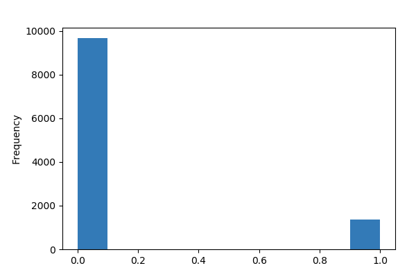

**Common Values**

| Value | Count | Frequency (%) |  |
| --- | --- | --- | --- |
| 0.0 | 9668 | 86.1% |  |
| 1.0 | 1375 | 12.2% |  |
| (Missing) | 188 | 1.7% |  |

**Extreme Values**

Minimum 5 values

| Value | Count | Frequency (%) |  |
| --- | --- | --- | --- |
| 0.0 | 9668 | 86.1% |  |
| 1.0 | 1375 | 12.2% |  |

Maximum 5 values

| Value | Count | Frequency (%) |  |
| --- | --- | --- | --- |
| 0.0 | 9668 | 86.1% |  |
| 1.0 | 1375 | 12.2% |  |

ARR_DELAY  
Highly correlated

*This variable is highly correlated with `DEP_DELAY` and should be ignored for analysis*

| Correlation | 0.93527 |
| --- | --- |

ARR_TIME  
Numeric

| Distinct count | 1214 |
| --- | --- |
| Unique (%) | 10.8% |
| Missing (%) | 1.0% |
| Missing (n) | 115 |
| Infinite (%) | 0.0% |
| Infinite (n) | 0 |

| Mean | 1524 |
| --- | --- |
| Minimum | 1 |
| Maximum | 2400 |
| Zeros (%) | 0.0% |

Toggle details

**Statistics**

Quantile statistics

| Minimum | 1 |
| --- | --- |
| 5-th percentile | 713.75 |
| Q1 | 1135 |
| Median | 1547 |
| Q3 | 1945 |
| 95-th percentile | 2251 |
| Maximum | 2400 |
| Range | 2399 |
| Interquartile range | 810 |

Descriptive statistics

| Standard deviation | 512.54 |
| --- | --- |
| Coef of variation | 0.33631 |
| Kurtosis | -0.26705 |
| Mean | 1524 |
| MAD | 429.18 |
| Skewness | -0.42121 |
| Sum | 16941000 |
| Variance | 262690 |
| Memory size | 87.8 KiB |

**Histogram**

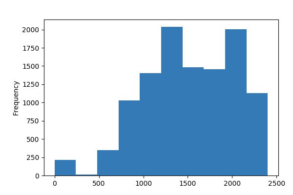

**Common Values**

| Value | Count | Frequency (%) |  |
| --- | --- | --- | --- |
| 1628.0 | 25 | 0.2% |  |
| 1335.0 | 25 | 0.2% |  |
| 1242.0 | 25 | 0.2% |  |
| 1946.0 | 24 | 0.2% |  |
| 1626.0 | 24 | 0.2% |  |
| 1943.0 | 24 | 0.2% |  |
| 1034.0 | 23 | 0.2% |  |
| 1038.0 | 23 | 0.2% |  |
| 2057.0 | 23 | 0.2% |  |
| 1037.0 | 23 | 0.2% |  |
| Other values (1203) | 10877 | 96.8% |  |
| (Missing) | 115 | 1.0% |  |

**Extreme Values**

Minimum 5 values

| Value | Count | Frequency (%) |  |
| --- | --- | --- | --- |
| 1.0 | 6 | 0.1% |  |
| 2.0 | 8 | 0.1% |  |
| 3.0 | 13 | 0.1% |  |
| 4.0 | 5 | 0.0% |  |
| 5.0 | 7 | 0.1% |  |

Maximum 5 values

| Value | Count | Frequency (%) |  |
| --- | --- | --- | --- |
| 2356.0 | 7 | 0.1% |  |
| 2357.0 | 4 | 0.0% |  |
| 2358.0 | 6 | 0.1% |  |
| 2359.0 | 8 | 0.1% |  |
| 2400.0 | 4 | 0.0% |  |

CANCELLED  
Boolean

| Distinct count | 2 |
| --- | --- |
| Unique (%) | 0.0% |
| Missing (%) | 0.0% |
| Missing (n) | 0 |

| Mean | 0.01015 |
| --- | --- |

| 0.0 | 11117 |
| --- | --- |
| 1.0 | 114 |

Toggle details

| Value | Count | Frequency (%) |  |
| --- | --- | --- | --- |
| 0.0 | 11117 | 99.0% |  |
| 1.0 | 114 | 1.0% |  |

CRS_ARR_TIME  
Numeric

| Distinct count | 958 |
| --- | --- |
| Unique (%) | 8.5% |
| Missing (%) | 0.0% |
| Missing (n) | 0 |
| Infinite (%) | 0.0% |
| Infinite (n) | 0 |

| Mean | 1537.3 |
| --- | --- |
| Minimum | 2 |
| Maximum | 2359 |
| Zeros (%) | 0.0% |

Toggle details

**Statistics**

Quantile statistics

| Minimum | 2 |
| --- | --- |
| 5-th percentile | 746.5 |
| Q1 | 1130 |
| Median | 1559 |
| Q3 | 1952 |
| 95-th percentile | 2252 |
| Maximum | 2359 |
| Range | 2357 |
| Interquartile range | 822 |

Descriptive statistics

| Standard deviation | 502.51 |
| --- | --- |
| Coef of variation | 0.32688 |
| Kurtosis | -0.25355 |
| Mean | 1537.3 |
| MAD | 421.94 |
| Skewness | -0.40779 |
| Sum | 17265560 |
| Variance | 252520 |
| Memory size | 87.8 KiB |

**Histogram**

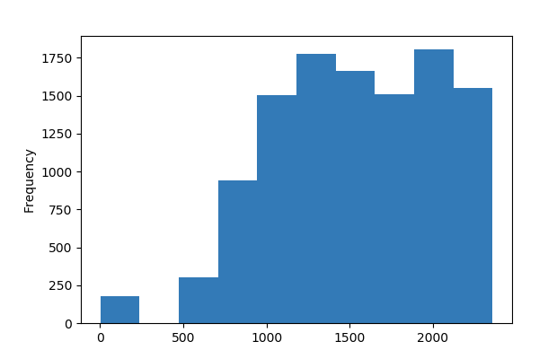

**Common Values**

| Value | Count | Frequency (%) |  |
| --- | --- | --- | --- |
| 1655 | 81 | 0.7% |  |
| 1840 | 72 | 0.6% |  |
| 1945 | 64 | 0.6% |  |
| 1345 | 54 | 0.5% |  |
| 1051 | 54 | 0.5% |  |
| 2130 | 53 | 0.5% |  |
| 1653 | 53 | 0.5% |  |
| 1415 | 51 | 0.5% |  |
| 845 | 50 | 0.4% |  |
| 1255 | 50 | 0.4% |  |
| Other values (948) | 10649 | 94.8% |  |

**Extreme Values**

Minimum 5 values

| Value | Count | Frequency (%) |  |
| --- | --- | --- | --- |
| 2 | 16 | 0.1% |  |
| 3 | 2 | 0.0% |  |
| 4 | 13 | 0.1% |  |
| 5 | 12 | 0.1% |  |
| 6 | 4 | 0.0% |  |

Maximum 5 values

| Value | Count | Frequency (%) |  |
| --- | --- | --- | --- |
| 2353 | 5 | 0.0% |  |
| 2356 | 3 | 0.0% |  |
| 2357 | 16 | 0.1% |  |
| 2358 | 14 | 0.1% |  |
| 2359 | 21 | 0.2% |  |

CRS_DEP_TIME  
Numeric

| Distinct count | 551 |
| --- | --- |
| Unique (%) | 4.9% |
| Missing (%) | 0.0% |
| Missing (n) | 0 |
| Infinite (%) | 0.0% |
| Infinite (n) | 0 |

| Mean | 1320.8 |
| --- | --- |
| Minimum | 10 |
| Maximum | 2359 |
| Zeros (%) | 0.0% |

Toggle details

**Statistics**

Quantile statistics

| Minimum | 10 |
| --- | --- |
| 5-th percentile | 620 |
| Q1 | 905 |
| Median | 1320 |
| Q3 | 1735 |
| 95-th percentile | 2115 |
| Maximum | 2359 |
| Range | 2349 |
| Interquartile range | 830 |

Descriptive statistics

| Standard deviation | 490.74 |
| --- | --- |
| Coef of variation | 0.37155 |
| Kurtosis | -0.76281 |
| Mean | 1320.8 |
| MAD | 415.77 |
| Skewness | 0.060403 |
| Sum | 14833886 |
| Variance | 240820 |
| Memory size | 87.8 KiB |

**Histogram**

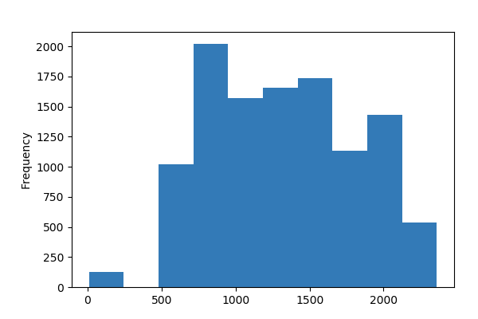

**Common Values**

| Value | Count | Frequency (%) |  |
| --- | --- | --- | --- |
| 1205 | 206 | 1.8% |  |
| 700 | 181 | 1.6% |  |
| 600 | 144 | 1.3% |  |
| 725 | 142 | 1.3% |  |
| 830 | 141 | 1.3% |  |
| 1345 | 137 | 1.2% |  |
| 1745 | 135 | 1.2% |  |
| 1925 | 125 | 1.1% |  |
| 1755 | 121 | 1.1% |  |
| 1530 | 117 | 1.0% |  |
| Other values (541) | 9782 | 87.1% |  |

**Extreme Values**

Minimum 5 values

| Value | Count | Frequency (%) |  |
| --- | --- | --- | --- |
| 10 | 2 | 0.0% |  |
| 20 | 4 | 0.0% |  |
| 23 | 12 | 0.1% |  |
| 25 | 13 | 0.1% |  |
| 30 | 8 | 0.1% |  |

Maximum 5 values

| Value | Count | Frequency (%) |  |
| --- | --- | --- | --- |
| 2345 | 7 | 0.1% |  |
| 2350 | 3 | 0.0% |  |
| 2355 | 1 | 0.0% |  |
| 2356 | 1 | 0.0% |  |
| 2359 | 9 | 0.1% |  |

CRS_ELAPSED_TIME  
Numeric

| Distinct count | 275 |
| --- | --- |
| Unique (%) | 2.4% |
| Missing (%) | 0.0% |
| Missing (n) | 0 |
| Infinite (%) | 0.0% |
| Infinite (n) | 0 |

| Mean | 190.65 |
| --- | --- |
| Minimum | 93 |
| Maximum | 397 |
| Zeros (%) | 0.0% |

Toggle details

**Statistics**

Quantile statistics

| Minimum | 93 |
| --- | --- |
| 5-th percentile | 106 |
| Q1 | 127 |
| Median | 159 |
| Q3 | 255 |
| 95-th percentile | 336 |
| Maximum | 397 |
| Range | 304 |
| Interquartile range | 128 |

Descriptive statistics

| Standard deviation | 78.386 |
| --- | --- |
| Coef of variation | 0.41115 |
| Kurtosis | -0.44499 |
| Mean | 190.65 |
| MAD | 66.266 |
| Skewness | 0.90401 |
| Sum | 2141200 |
| Variance | 6144.4 |
| Memory size | 87.8 KiB |

**Histogram**

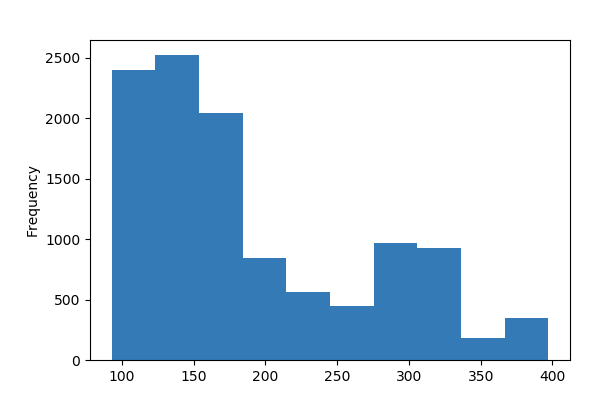

**Common Values**

| Value | Count | Frequency (%) |  |
| --- | --- | --- | --- |
| 120.0 | 309 | 2.8% |  |
| 119.0 | 190 | 1.7% |  |
| 123.0 | 190 | 1.7% |  |
| 160.0 | 181 | 1.6% |  |
| 124.0 | 169 | 1.5% |  |
| 153.0 | 163 | 1.5% |  |
| 154.0 | 163 | 1.5% |  |
| 122.0 | 160 | 1.4% |  |
| 121.0 | 157 | 1.4% |  |
| 125.0 | 156 | 1.4% |  |
| Other values (265) | 9393 | 83.6% |  |

**Extreme Values**

Minimum 5 values

| Value | Count | Frequency (%) |  |
| --- | --- | --- | --- |
| 93.0 | 1 | 0.0% |  |
| 95.0 | 3 | 0.0% |  |
| 96.0 | 1 | 0.0% |  |
| 97.0 | 13 | 0.1% |  |
| 98.0 | 29 | 0.3% |  |

Maximum 5 values

| Value | Count | Frequency (%) |  |
| --- | --- | --- | --- |
| 390.0 | 14 | 0.1% |  |
| 391.0 | 5 | 0.0% |  |
| 392.0 | 7 | 0.1% |  |
| 393.0 | 12 | 0.1% |  |
| 397.0 | 5 | 0.0% |  |

DAY_OF_MONTH  
Numeric

| Distinct count | 31 |
| --- | --- |
| Unique (%) | 0.3% |
| Missing (%) | 0.0% |
| Missing (n) | 0 |
| Infinite (%) | 0.0% |
| Infinite (n) | 0 |

| Mean | 15.791 |
| --- | --- |
| Minimum | 1 |
| Maximum | 31 |
| Zeros (%) | 0.0% |

Toggle details

**Statistics**

Quantile statistics

| Minimum | 1 |
| --- | --- |
| 5-th percentile | 2 |
| Q1 | 8 |
| Median | 16 |
| Q3 | 23 |
| 95-th percentile | 29 |
| Maximum | 31 |
| Range | 30 |
| Interquartile range | 15 |

Descriptive statistics

| Standard deviation | 8.7821 |
| --- | --- |
| Coef of variation | 0.55615 |
| Kurtosis | -1.1906 |
| Mean | 15.791 |
| MAD | 7.6007 |
| Skewness | -0.00071188 |
| Sum | 177346 |
| Variance | 77.125 |
| Memory size | 87.8 KiB |

**Histogram**

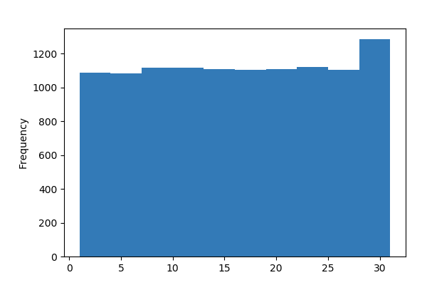

**Common Values**

| Value | Count | Frequency (%) |  |
| --- | --- | --- | --- |
| 8 | 390 | 3.5% |  |
| 23 | 381 | 3.4% |  |
| 28 | 379 | 3.4% |  |
| 11 | 378 | 3.4% |  |
| 14 | 378 | 3.4% |  |
| 21 | 378 | 3.4% |  |
| 22 | 376 | 3.3% |  |
| 26 | 375 | 3.3% |  |
| 18 | 373 | 3.3% |  |
| 9 | 372 | 3.3% |  |
| Other values (21) | 7451 | 66.3% |  |

**Extreme Values**

Minimum 5 values

| Value | Count | Frequency (%) |  |
| --- | --- | --- | --- |
| 1 | 363 | 3.2% |  |
| 2 | 371 | 3.3% |  |
| 3 | 351 | 3.1% |  |
| 4 | 360 | 3.2% |  |
| 5 | 366 | 3.3% |  |

Maximum 5 values

| Value | Count | Frequency (%) |  |
| --- | --- | --- | --- |
| 27 | 368 | 3.3% |  |
| 28 | 379 | 3.4% |  |
| 29 | 361 | 3.2% |  |
| 30 | 335 | 3.0% |  |
| 31 | 209 | 1.9% |  |

DAY_OF_WEEK  
Numeric

| Distinct count | 7 |
| --- | --- |
| Unique (%) | 0.1% |
| Missing (%) | 0.0% |
| Missing (n) | 0 |
| Infinite (%) | 0.0% |
| Infinite (n) | 0 |

| Mean | 3.9602 |
| --- | --- |
| Minimum | 1 |
| Maximum | 7 |
| Zeros (%) | 0.0% |

Toggle details

**Statistics**

Quantile statistics

| Minimum | 1 |
| --- | --- |
| 5-th percentile | 1 |
| Q1 | 2 |
| Median | 4 |
| Q3 | 6 |
| 95-th percentile | 7 |
| Maximum | 7 |
| Range | 6 |
| Interquartile range | 4 |

Descriptive statistics

| Standard deviation | 1.9953 |
| --- | --- |
| Coef of variation | 0.50383 |
| Kurtosis | -1.2299 |
| Mean | 3.9602 |
| MAD | 1.7095 |
| Skewness | 0.02841 |
| Sum | 44477 |
| Variance | 3.9811 |
| Memory size | 87.8 KiB |

**Histogram**

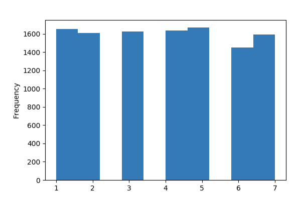

**Common Values**

| Value | Count | Frequency (%) |  |
| --- | --- | --- | --- |
| 5 | 1668 | 14.9% |  |
| 1 | 1652 | 14.7% |  |
| 4 | 1637 | 14.6% |  |
| 3 | 1624 | 14.5% |  |
| 2 | 1607 | 14.3% |  |
| 7 | 1593 | 14.2% |  |
| 6 | 1450 | 12.9% |  |

**Extreme Values**

Minimum 5 values

| Value | Count | Frequency (%) |  |
| --- | --- | --- | --- |
| 1 | 1652 | 14.7% |  |
| 2 | 1607 | 14.3% |  |
| 3 | 1624 | 14.5% |  |
| 4 | 1637 | 14.6% |  |
| 5 | 1668 | 14.9% |  |

Maximum 5 values

| Value | Count | Frequency (%) |  |
| --- | --- | --- | --- |
| 3 | 1624 | 14.5% |  |
| 4 | 1637 | 14.6% |  |
| 5 | 1668 | 14.9% |  |
| 6 | 1450 | 12.9% |  |
| 7 | 1593 | 14.2% |  |

DEP_DEL15  
Numeric

| Distinct count | 3 |
| --- | --- |
| Unique (%) | 0.0% |
| Missing (%) | 1.0% |
| Missing (n) | 107 |
| Infinite (%) | 0.0% |
| Infinite (n) | 0 |

| Mean | 0.14284 |
| --- | --- |
| Minimum | 0 |
| Maximum | 1 |
| Zeros (%) | 84.9% |

Toggle details

**Statistics**

Quantile statistics

| Minimum | 0 |
| --- | --- |
| 5-th percentile | 0 |
| Q1 | 0 |
| Median | 0 |
| Q3 | 0 |
| 95-th percentile | 1 |
| Maximum | 1 |
| Range | 1 |
| Interquartile range | 0 |

Descriptive statistics

| Standard deviation | 0.34993 |
| --- | --- |
| Coef of variation | 2.4497 |
| Kurtosis | 2.1688 |
| Mean | 0.14284 |
| MAD | 0.24488 |
| Skewness | 2.0417 |
| Sum | 1589 |
| Variance | 0.12245 |
| Memory size | 87.8 KiB |

**Histogram**

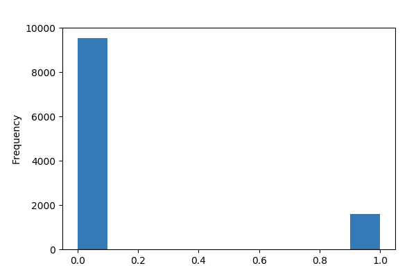

**Common Values**

| Value | Count | Frequency (%) |  |
| --- | --- | --- | --- |
| 0.0 | 9535 | 84.9% |  |
| 1.0 | 1589 | 14.1% |  |
| (Missing) | 107 | 1.0% |  |

**Extreme Values**

Minimum 5 values

| Value | Count | Frequency (%) |  |
| --- | --- | --- | --- |
| 0.0 | 9535 | 84.9% |  |
| 1.0 | 1589 | 14.1% |  |

Maximum 5 values

| Value | Count | Frequency (%) |  |
| --- | --- | --- | --- |
| 0.0 | 9535 | 84.9% |  |
| 1.0 | 1589 | 14.1% |  |

DEP_DELAY  
Numeric

| Distinct count | 275 |
| --- | --- |
| Unique (%) | 2.4% |
| Missing (%) | 1.0% |
| Missing (n) | 107 |
| Infinite (%) | 0.0% |
| Infinite (n) | 0 |

| Mean | 8.4603 |
| --- | --- |
| Minimum | -16 |
| Maximum | 645 |
| Zeros (%) | 9.1% |

Toggle details

**Statistics**

Quantile statistics

| Minimum | -16 |
| --- | --- |
| 5-th percentile | -6 |
| Q1 | -3 |
| Median | -1 |
| Q3 | 4 |
| 95-th percentile | 51 |
| Maximum | 645 |
| Range | 661 |
| Interquartile range | 7 |

Descriptive statistics

| Standard deviation | 36.763 |
| --- | --- |
| Coef of variation | 4.3454 |
| Kurtosis | 68.902 |
| Mean | 8.4603 |
| MAD | 16.181 |
| Skewness | 7.0931 |
| Sum | 94112 |
| Variance | 1351.5 |
| Memory size | 87.8 KiB |

**Histogram**

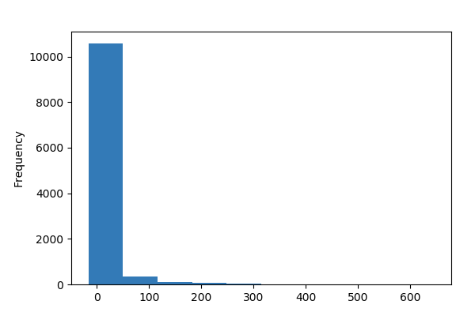

**Common Values**

| Value | Count | Frequency (%) |  |
| --- | --- | --- | --- |
| -2.0 | 1384 | 12.3% |  |
| -1.0 | 1306 | 11.6% |  |
| -3.0 | 1152 | 10.3% |  |
| 0.0 | 1024 | 9.1% |  |
| -4.0 | 870 | 7.7% |  |
| -5.0 | 646 | 5.8% |  |
| -6.0 | 444 | 4.0% |  |
| 1.0 | 399 | 3.6% |  |
| 2.0 | 245 | 2.2% |  |
| 3.0 | 235 | 2.1% |  |
| Other values (264) | 3419 | 30.4% |  |

**Extreme Values**

Minimum 5 values

| Value | Count | Frequency (%) |  |
| --- | --- | --- | --- |
| -16.0 | 1 | 0.0% |  |
| -15.0 | 2 | 0.0% |  |
| -13.0 | 3 | 0.0% |  |
| -12.0 | 7 | 0.1% |  |
| -11.0 | 13 | 0.1% |  |

Maximum 5 values

| Value | Count | Frequency (%) |  |
| --- | --- | --- | --- |
| 501.0 | 1 | 0.0% |  |
| 517.0 | 1 | 0.0% |  |
| 561.0 | 1 | 0.0% |  |
| 625.0 | 1 | 0.0% |  |
| 645.0 | 1 | 0.0% |  |

DEP_TIME  
Highly correlated

*This variable is highly correlated with `CRS_DEP_TIME` and should be ignored for analysis*

| Correlation | 0.96964 |
| --- | --- |

DEST  
Categorical

| Distinct count | 5 |
| --- | --- |
| Unique (%) | 0.0% |
| Missing (%) | 0.0% |
| Missing (n) | 0 |

| ATL | 3221 |
| --- | --- |
| MSP | 2493 |
| DTW | 2211 |
| Other values (2) | 3306 |

Toggle details

| Value | Count | Frequency (%) |  |
| --- | --- | --- | --- |
| ATL | 3221 | 28.7% |  |
| MSP | 2493 | 22.2% |  |
| DTW | 2211 | 19.7% |  |
| SEA | 1994 | 17.8% |  |
| JFK | 1312 | 11.7% |  |

DEST_AIRPORT_ID  
Numeric

| Distinct count | 5 |
| --- | --- |
| Unique (%) | 0.0% |
| Missing (%) | 0.0% |
| Missing (n) | 0 |
| Infinite (%) | 0.0% |
| Infinite (n) | 0 |

| Mean | 12302 |
| --- | --- |
| Minimum | 10397 |
| Maximum | 14747 |
| Zeros (%) | 0.0% |

Toggle details

**Statistics**

Quantile statistics

| Minimum | 10397 |
| --- | --- |
| 5-th percentile | 10397 |
| Q1 | 10397 |
| Median | 12478 |
| Q3 | 13487 |
| 95-th percentile | 14747 |
| Maximum | 14747 |
| Range | 4350 |
| Interquartile range | 3090 |

Descriptive statistics

| Standard deviation | 1602 |
| --- | --- |
| Coef of variation | 0.13022 |
| Kurtosis | -1.3796 |
| Mean | 12302 |
| MAD | 1435.1 |
| Skewness | 0.20705 |
| Sum | 138166845 |
| Variance | 2566400 |
| Memory size | 87.8 KiB |

**Histogram**

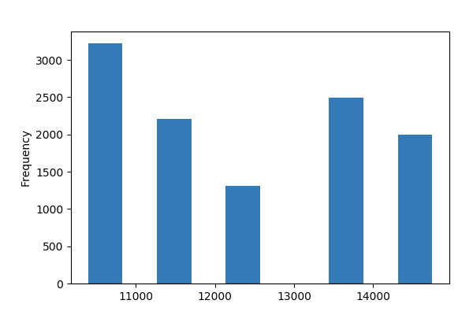

**Common Values**

| Value | Count | Frequency (%) |  |
| --- | --- | --- | --- |
| 10397 | 3221 | 28.7% |  |
| 13487 | 2493 | 22.2% |  |
| 11433 | 2211 | 19.7% |  |
| 14747 | 1994 | 17.8% |  |
| 12478 | 1312 | 11.7% |  |

**Extreme Values**

Minimum 5 values

| Value | Count | Frequency (%) |  |
| --- | --- | --- | --- |
| 10397 | 3221 | 28.7% |  |
| 11433 | 2211 | 19.7% |  |
| 12478 | 1312 | 11.7% |  |
| 13487 | 2493 | 22.2% |  |
| 14747 | 1994 | 17.8% |  |

Maximum 5 values

| Value | Count | Frequency (%) |  |
| --- | --- | --- | --- |
| 10397 | 3221 | 28.7% |  |
| 11433 | 2211 | 19.7% |  |
| 12478 | 1312 | 11.7% |  |
| 13487 | 2493 | 22.2% |  |
| 14747 | 1994 | 17.8% |  |

DISTANCE  
Highly correlated

*This variable is highly correlated with `ACTUAL_ELAPSED_TIME` and should be ignored for analysis*

| Correlation | 0.96649 |
| --- | --- |

DIVERTED  
Boolean

| Distinct count | 2 |
| --- | --- |
| Unique (%) | 0.0% |
| Missing (%) | 0.0% |
| Missing (n) | 0 |

| Mean | 0.0065889 |
| --- | --- |

| 0.0 | 11157 |
| --- | --- |
| 1.0 | 74 |

Toggle details

| Value | Count | Frequency (%) |  |
| --- | --- | --- | --- |
| 0.0 | 11157 | 99.3% |  |
| 1.0 | 74 | 0.7% |  |

FL_NUM  
Numeric

| Distinct count | 690 |
| --- | --- |
| Unique (%) | 6.1% |
| Missing (%) | 0.0% |
| Missing (n) | 0 |
| Infinite (%) | 0.0% |
| Infinite (n) | 0 |

| Mean | 1334.3 |
| --- | --- |
| Minimum | 7 |
| Maximum | 2853 |
| Zeros (%) | 0.0% |

Toggle details

**Statistics**

Quantile statistics

| Minimum | 7 |
| --- | --- |
| 5-th percentile | 87 |
| Q1 | 624 |
| Median | 1267 |
| Q3 | 2032 |
| 95-th percentile | 2659 |
| Maximum | 2853 |
| Range | 2846 |
| Interquartile range | 1408 |

Descriptive statistics

| Standard deviation | 811.88 |
| --- | --- |
| Coef of variation | 0.60845 |
| Kurtosis | -1.1431 |
| Mean | 1334.3 |
| MAD | 703.8 |
| Skewness | 0.17938 |
| Sum | 14985811 |
| Variance | 659140 |
| Memory size | 87.8 KiB |

**Histogram**

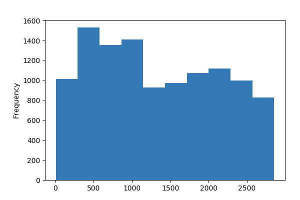

**Common Values**

| Value | Count | Frequency (%) |  |
| --- | --- | --- | --- |
| 888 | 98 | 0.9% |  |
| 589 | 96 | 0.9% |  |
| 1991 | 96 | 0.9% |  |
| 588 | 95 | 0.8% |  |
| 902 | 94 | 0.8% |  |
| 630 | 92 | 0.8% |  |
| 325 | 92 | 0.8% |  |
| 1598 | 92 | 0.8% |  |
| 2283 | 92 | 0.8% |  |
| 1768 | 90 | 0.8% |  |
| Other values (680) | 10294 | 91.7% |  |

**Extreme Values**

Minimum 5 values

| Value | Count | Frequency (%) |  |
| --- | --- | --- | --- |
| 7 | 4 | 0.0% |  |
| 8 | 11 | 0.1% |  |
| 16 | 57 | 0.5% |  |
| 17 | 50 | 0.4% |  |
| 22 | 33 | 0.3% |  |

Maximum 5 values

| Value | Count | Frequency (%) |  |
| --- | --- | --- | --- |
| 2848 | 5 | 0.0% |  |
| 2849 | 1 | 0.0% |  |
| 2850 | 1 | 0.0% |  |
| 2852 | 1 | 0.0% |  |
| 2853 | 12 | 0.1% |  |

MONTH  
Highly correlated

*This variable is highly correlated with `QUARTER` and should be ignored for analysis*

| Correlation | 0.96989 |
| --- | --- |

ORIGIN  
Categorical

| Distinct count | 5 |
| --- | --- |
| Unique (%) | 0.0% |
| Missing (%) | 0.0% |
| Missing (n) | 0 |

| ATL | 3100 |
| --- | --- |
| MSP | 2538 |
| DTW | 2201 |
| Other values (2) | 3392 |

Toggle details

| Value | Count | Frequency (%) |  |
| --- | --- | --- | --- |
| ATL | 3100 | 27.6% |  |
| MSP | 2538 | 22.6% |  |
| DTW | 2201 | 19.6% |  |
| SEA | 2018 | 18.0% |  |
| JFK | 1374 | 12.2% |  |

ORIGIN_AIRPORT_ID  
Numeric

| Distinct count | 5 |
| --- | --- |
| Unique (%) | 0.0% |
| Missing (%) | 0.0% |
| Missing (n) | 0 |
| Infinite (%) | 0.0% |
| Infinite (n) | 0 |

| Mean | 12335 |
| --- | --- |
| Minimum | 10397 |
| Maximum | 14747 |
| Zeros (%) | 0.0% |

Toggle details

**Statistics**

Quantile statistics

| Minimum | 10397 |
| --- | --- |
| 5-th percentile | 10397 |
| Q1 | 10397 |
| Median | 12478 |
| Q3 | 13487 |
| 95-th percentile | 14747 |
| Maximum | 14747 |
| Range | 4350 |
| Interquartile range | 3090 |

Descriptive statistics

| Standard deviation | 1595 |
| --- | --- |
| Coef of variation | 0.12931 |
| Kurtosis | -1.3769 |
| Mean | 12335 |
| MAD | 1422.9 |
| Skewness | 0.17697 |
| Sum | 138528957 |
| Variance | 2544100 |
| Memory size | 87.8 KiB |

**Histogram**

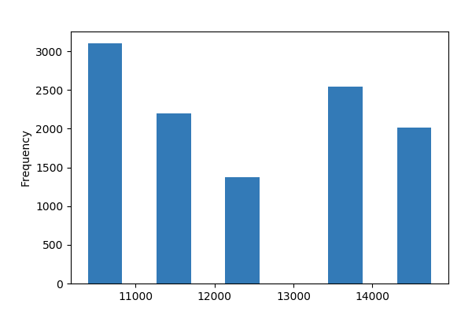

**Common Values**

| Value | Count | Frequency (%) |  |
| --- | --- | --- | --- |
| 10397 | 3100 | 27.6% |  |
| 13487 | 2538 | 22.6% |  |
| 11433 | 2201 | 19.6% |  |
| 14747 | 2018 | 18.0% |  |
| 12478 | 1374 | 12.2% |  |

**Extreme Values**

Minimum 5 values

| Value | Count | Frequency (%) |  |
| --- | --- | --- | --- |
| 10397 | 3100 | 27.6% |  |
| 11433 | 2201 | 19.6% |  |
| 12478 | 1374 | 12.2% |  |
| 13487 | 2538 | 22.6% |  |
| 14747 | 2018 | 18.0% |  |

Maximum 5 values

| Value | Count | Frequency (%) |  |
| --- | --- | --- | --- |
| 10397 | 3100 | 27.6% |  |
| 11433 | 2201 | 19.6% |  |
| 12478 | 1374 | 12.2% |  |
| 13487 | 2538 | 22.6% |  |
| 14747 | 2018 | 18.0% |  |

QUARTER  
Numeric

| Distinct count | 4 |
| --- | --- |
| Unique (%) | 0.0% |
| Missing (%) | 0.0% |
| Missing (n) | 0 |
| Infinite (%) | 0.0% |
| Infinite (n) | 0 |

| Mean | 2.5445 |
| --- | --- |
| Minimum | 1 |
| Maximum | 4 |
| Zeros (%) | 0.0% |

Toggle details

**Statistics**

Quantile statistics

| Minimum | 1 |
| --- | --- |
| 5-th percentile | 1 |
| Q1 | 2 |
| Median | 3 |
| Q3 | 3 |
| 95-th percentile | 4 |
| Maximum | 4 |
| Range | 3 |
| Interquartile range | 1 |

Descriptive statistics

| Standard deviation | 1.0907 |
| --- | --- |
| Coef of variation | 0.42865 |
| Kurtosis | -1.2906 |
| Mean | 2.5445 |
| MAD | 0.9684 |
| Skewness | -0.072046 |
| Sum | 28577 |
| Variance | 1.1896 |
| Memory size | 87.8 KiB |

**Histogram**

[3 more figures not shown]

Sample

|  | YEAR | QUARTER | MONTH | DAY_OF_MONTH | DAY_OF_WEEK | UNIQUE_CARRIER | TAIL_NUM | FL_NUM | ORIGIN_AIRPORT_ID | ORIGIN | DEST_AIRPORT_ID | DEST | CRS_DEP_TIME | DEP_TIME | DEP_DELAY | DEP_DEL15 | CRS_ARR_TIME | ARR_TIME | ARR_DELAY | ARR_DEL15 | CANCELLED | DIVERTED | CRS_ELAPSED_TIME | ACTUAL_ELAPSED_TIME | DISTANCE | Unnamed: 25 |
| --- | --- | --- | --- | --- | --- | --- | --- | --- | --- | --- | --- | --- | --- | --- | --- | --- | --- | --- | --- | --- | --- | --- | --- | --- | --- | --- |
| 0 | 2016 | 1 | 1 | 1 | 5 | DL | N836DN | 1399 | 10397 | ATL | 14747 | SEA | 1905 | 1907.0 | 2.0 | 0.0 | 2143 | 2102.0 | -41.0 | 0.0 | 0.0 | 0.0 | 338.0 | 295.0 | 2182.0 | NaN |
| 1 | 2016 | 1 | 1 | 1 | 5 | DL | N964DN | 1476 | 11433 | DTW | 13487 | MSP | 1345 | 1344.0 | -1.0 | 0.0 | 1435 | 1439.0 | 4.0 | 0.0 | 0.0 | 0.0 | 110.0 | 115.0 | 528.0 | NaN |
| 2 | 2016 | 1 | 1 | 1 | 5 | DL | N813DN | 1597 | 10397 | ATL | 14747 | SEA | 940 | 942.0 | 2.0 | 0.0 | 1215 | 1142.0 | -33.0 | 0.0 | 0.0 | 0.0 | 335.0 | 300.0 | 2182.0 | NaN |
| 3 | 2016 | 1 | 1 | 1 | 5 | DL | N587NW | 1768 | 14747 | SEA | 13487 | MSP | 819 | 820.0 | 1.0 | 0.0 | 1335 | 1345.0 | 10.0 | 0.0 | 0.0 | 0.0 | 196.0 | 205.0 | 1399.0 | NaN |
| 4 | 2016 | 1 | 1 | 1 | 5 | DL | N836DN | 1823 | 14747 | SEA | 11433 | DTW | 2300 | 2256.0 | -4.0 | 0.0 | 607 | 615.0 | 8.0 | 0.0 | 0.0 | 0.0 | 247.0 | 259.0 | 1927.0 | NaN |

```python
pdp.ProfileReport(df)
```

Now take a moment to examine the 26 columns in the dataset. They contain important information such as the date that the flight took place (YEAR, MONTH, and DAY_OF_MONTH), the origin and destination (ORIGIN and DEST), the scheduled departure and arrival times (CRS_DEP_TIME and CRS_ARR_TIME), the difference between the scheduled arrival time and the actual arrival time in minutes (ARR_DELAY), and whether the flight was late by 15 minutes or more (ARR_DEL15).

Here is a complete list of the columns in the dataset. Times are expressed in 24-hour military time. For example, 1130 equals 11:30 a.m. and 1500 equals 3:00 p.m.

| Column | Description |
| --- | --- |
| YEAR | Year that the flight took place |
| QUARTER | Quarter that the flight took place (1-4) |
| MONTH | Month that the flight took place (1-12) |
| DAY_OF_MONTH | Day of the month that the flight took place (1-31) |
| DAY_OF_WEEK | Day of the week that the flight took place (1=Monday, 2=Tuesday, etc.) |
| UNIQUE_CARRIER | Airline carrier code (e.g., DL) |
| TAIL_NUM | Aircraft tail number |
| FL_NUM | Flight number |
| ORIGIN_AIRPORT_ID | ID of the airport of origin |
| ORIGIN | Origin airport code (ATL, DFW, SEA, etc.) |
| DEST_AIRPORT_ID | ID of the destination airport |
| DEST | Destination airport code (ATL, DFW, SEA, etc.) |
| CRS_DEP_TIME | Scheduled departure time |
| DEP_TIME | Actual departure time |
| DEP_DELAY | Number of minutes departure was delayed |
| DEP_DEL15 | 0=Departure delayed less than 15 minutes 1=Departure delayed 15 minutes or more |
| CRS_ARR_TIME | Scheduled arrival time |
| ARR_TIME | Actual arrival time |
| ARR_DELAY | Number of minutes flight arrived late |
| ARR_DEL15 | 0=Arrived less than 15 minutes late 1=Arrived 15 minutes or more late |
| CANCELLED | 0=Flight was not cancelled 1=Flight was cancelled |
| DIVERTED | 0=Flight was not diverted 1=Flight was diverted |
| CRS_ELAPSED_TIME | Scheduled flight time in minutes |
| ACTUAL_ELAPSED_TIME | Actual flight time in minutes |
| DISTANCE | Distance traveled in miles |

The dataset includes a roughly even distribution of dates throughout the year, which is important because a flight out of Minneapolis is less likely to be delayed due to winter storms in July than it is in January. But this dataset is far from being "clean" and ready to use. Let's write some Pandas code to clean it up.

### Data Cleaning

```python
print('is it true that there are missing values ?',df.isnull().values.any())
```

```
is it true that there are missing values ? True
```

```python
df.isnull().sum()
```

```
YEAR                       0
QUARTER                    0
MONTH                      0
DAY_OF_MONTH               0
DAY_OF_WEEK                0
UNIQUE_CARRIER             0
TAIL_NUM                   0
FL_NUM                     0
ORIGIN_AIRPORT_ID          0
ORIGIN                     0
DEST_AIRPORT_ID            0
DEST                       0
CRS_DEP_TIME               0
DEP_TIME                 107
DEP_DELAY                107
DEP_DEL15                107
CRS_ARR_TIME               0
ARR_TIME                 115
ARR_DELAY                188
ARR_DEL15                188
CANCELLED                  0
DIVERTED                   0
CRS_ELAPSED_TIME           0
ACTUAL_ELAPSED_TIME      188
DISTANCE                   0
Unnamed: 25            11231
dtype: int64
```

```python
df = df[["MONTH", "DAY_OF_MONTH", "DAY_OF_WEEK", "ORIGIN", "DEST", "CRS_DEP_TIME", "ARR_DEL15"]]
df.isnull().sum()
```

```
MONTH             0
DAY_OF_MONTH      0
DAY_OF_WEEK       0
ORIGIN            0
DEST              0
CRS_DEP_TIME      0
ARR_DEL15       188
dtype: int64
```

```python
df[df.isnull().values.any(axis=1)].head()
```

|  | MONTH | DAY_OF_MONTH | DAY_OF_WEEK | ORIGIN | DEST | CRS_DEP_TIME | ARR_DEL15 |
| --- | --- | --- | --- | --- | --- | --- | --- |
| 177 | 1 | 9 | 6 | MSP | SEA | 701 | NaN |
| 179 | 1 | 10 | 7 | MSP | DTW | 1348 | NaN |
| 184 | 1 | 10 | 7 | MSP | DTW | 625 | NaN |
| 210 | 1 | 10 | 7 | DTW | MSP | 1200 | NaN |
| 478 | 1 | 22 | 5 | SEA | JFK | 2305 | NaN |

```python
df = df.fillna({'ARR_DEL15': 1})
df.iloc[177:185]
```

|  | MONTH | DAY_OF_MONTH | DAY_OF_WEEK | ORIGIN | DEST | CRS_DEP_TIME | ARR_DEL15 |
| --- | --- | --- | --- | --- | --- | --- | --- |
| 177 | 1 | 9 | 6 | MSP | SEA | 701 | 1.0 |
| 178 | 1 | 9 | 6 | DTW | JFK | 1527 | 0.0 |
| 179 | 1 | 10 | 7 | MSP | DTW | 1348 | 1.0 |
| 180 | 1 | 10 | 7 | DTW | MSP | 1540 | 0.0 |
| 181 | 1 | 10 | 7 | JFK | ATL | 1325 | 0.0 |
| 182 | 1 | 10 | 7 | JFK | ATL | 610 | 0.0 |
| 183 | 1 | 10 | 7 | JFK | SEA | 1615 | 0.0 |
| 184 | 1 | 10 | 7 | MSP | DTW | 625 | 1.0 |

### Bin departure times and add indicator columns

The CRS_DEP_TIME column of the dataset you are using represents scheduled departure times. The granularity of the numbers in this column — it contains more than 500 unique values — could have a negative impact on accuracy in a machine-learning model. This can be resolved using a technique called binning or quantization. What if you divided each number in this column by 100 and rounded down to the nearest integer? 1030 would become 10, 1925 would become 19, and so on, and you would be left with a maximum of 24 discrete values in this column. Intuitively, it makes sense, because it probably doesn't matter much whether a flight leaves at 10:30 a.m. or 10:40 a.m. It matters a great deal whether it leaves at 10:30 a.m. or 5:30 p.m.

In addition, the dataset's ORIGIN and DEST columns contain airport codes that represent categorical machine-learning values. These columns need to be converted into discrete columns containing indicator variables, sometimes known as "dummy" variables. In other words, the ORIGIN column, which contains five airport codes, needs to be converted into five columns, one per airport, with each column containing 1s and 0s indicating whether a flight originated at the airport that the column represents. The DEST column needs to be handled in a similar manner.

```python
df.columns
```

```
Index(['MONTH', 'DAY_OF_MONTH', 'DAY_OF_WEEK', 'ORIGIN', 'DEST',
       'CRS_DEP_TIME', 'ARR_DEL15'],
      dtype='object')
```

```python
import math

for index, row in df.iterrows():
    df.loc[index, 'CRS_DEP_TIME'] = math.floor(row['CRS_DEP_TIME'] / 100)
df.head()
```

|  | MONTH | DAY_OF_MONTH | DAY_OF_WEEK | ORIGIN | DEST | CRS_DEP_TIME | ARR_DEL15 |
| --- | --- | --- | --- | --- | --- | --- | --- |
| 0 | 1 | 1 | 5 | ATL | SEA | 19 | 0.0 |
| 1 | 1 | 1 | 5 | DTW | MSP | 13 | 0.0 |
| 2 | 1 | 1 | 5 | ATL | SEA | 9 | 0.0 |
| 3 | 1 | 1 | 5 | SEA | MSP | 8 | 0.0 |
| 4 | 1 | 1 | 5 | SEA | DTW | 23 | 0.0 |

```python
df = pd.get_dummies(df, columns=['ORIGIN', 'DEST'])
df.head()
```

|  | MONTH | DAY_OF_MONTH | DAY_OF_WEEK | CRS_DEP_TIME | ARR_DEL15 | ORIGIN_ATL | ORIGIN_DTW | ORIGIN_JFK | ORIGIN_MSP | ORIGIN_SEA | DEST_ATL | DEST_DTW | DEST_JFK | DEST_MSP | DEST_SEA |
| --- | --- | --- | --- | --- | --- | --- | --- | --- | --- | --- | --- | --- | --- | --- | --- |
| 0 | 1 | 1 | 5 | 19 | 0.0 | 1 | 0 | 0 | 0 | 0 | 0 | 0 | 0 | 0 | 1 |
| 1 | 1 | 1 | 5 | 13 | 0.0 | 0 | 1 | 0 | 0 | 0 | 0 | 0 | 0 | 1 | 0 |
| 2 | 1 | 1 | 5 | 9 | 0.0 | 1 | 0 | 0 | 0 | 0 | 0 | 0 | 0 | 0 | 1 |
| 3 | 1 | 1 | 5 | 8 | 0.0 | 0 | 0 | 0 | 0 | 1 | 0 | 0 | 0 | 1 | 0 |
| 4 | 1 | 1 | 5 | 23 | 0.0 | 0 | 0 | 0 | 0 | 1 | 0 | 1 | 0 | 0 | 0 |

```python
df.shape
```

```
(11231, 15)
```

### Split Data for Train and Test

```python
from sklearn.model_selection import train_test_split
train_x, test_x, train_y, test_y = \
      train_test_split(df.drop('ARR_DEL15', axis=1), \
                    df['ARR_DEL15'], test_size=0.2, random_state=42)
```

```python
print(train_x.shape, test_x.shape)
```

```
(8984, 14) (2247, 14)
```

### Train ML Model using RandomForestClassifier

```python
from sklearn.ensemble import RandomForestClassifier

model = RandomForestClassifier(random_state=13)
model.fit(train_x, train_y)
```

```
RandomForestClassifier(bootstrap=True, class_weight=None, criterion='gini',
            max_depth=None, max_features='auto', max_leaf_nodes=None,
            min_impurity_decrease=0.0, min_impurity_split=None,
            min_samples_leaf=1, min_samples_split=2,
            min_weight_fraction_leaf=0.0, n_estimators=10, n_jobs=None,
            oob_score=False, random_state=13, verbose=0, warm_start=False)
```

```python
predicted = model.predict(test_x)
model.score(test_x, test_y)
```

```
0.8602581219403649
```

### Model Accuracy

```python
from sklearn.metrics import roc_auc_score
probabilities = model.predict_proba(test_x)
```

Generating an AUC score

Why is the AUC score lower than the mean accuracy computed in the previous exercise?

The output from the score method reflects how many of the items in the test set the model predicted correctly. This score is skewed by the fact that the dataset the model was trained and tested with contains many more rows representing on-time arrivals than rows representing late arrivals. Because of this imbalance in the data, you are more likely to be correct if you predict that a flight will be on time than if you predict that a flight will be late.

ROC AUC takes this into account and provides a more accurate indication of how likely it is that a prediction of on-time or late will be correct.

```python
roc_auc_score(test_y, probabilities[:, 1])
```

```
0.6743824904998539
```

Generating a confusion matrix

Find out more about the model's behavior by generating a confusion matrix, also known as an error matrix. The confusion matrix quantifies the number of times each answer was classified correctly or incorrectly. Specifically, it quantifies the number of false positives, false negatives, true positives, and true negatives. This is important, because if a binary classification model trained to recognize cats and dogs is tested with a dataset that is 95% dogs, it could score 95% simply by guessing "dog" every time. But if it failed to identify cats at all, it would be of little value.

But look at the second row, which represents flights that were delayed. The first column shows how many delayed flights were incorrectly predicted to be on time. The second column shows how many flights were correctly predicted to be delayed. Clearly, the model isn't nearly as adept at predicting that a flight will be delayed as it is at predicting that a flight will arrive on time. What you want in a confusion matrix is big numbers in the upper-left and lower-right corners, and small numbers (preferably zeros) in the upper-right and lower-left corners.

```python
from sklearn.metrics import confusion_matrix
confusion_matrix(test_y, predicted)
```

```
array([[1882,   54],
       [ 260,   51]], dtype=int64)
```

Other measures of accuracy for a classification model include precision and recall. Suppose the model was presented with three on-time arrivals and three delayed arrivals, and that it correctly predicted two of the on-time arrivals, but incorrectly predicted that two of the delayed arrivals would be on time. In this case, the precision would be 50% (two of the four flights it classified as being on time actually were on time), while its recall would be 67% (it correctly identified two of the three on-time arrivals).

More about precision and recall from https://en.wikipedia.org/wiki/Precision_and_recall

Sckit-learn contains a handy method named precision_score for computing precision.

```python
from sklearn.metrics import precision_score

train_predictions = model.predict(train_x)
precision_score(train_y, train_predictions)
```

```
0.9972375690607734
```

Measuring precision

Sckit-learn also contains a method named recall_score for computing recall.

```python
from sklearn.metrics import recall_score

recall_score(train_y, train_predictions)
```

```
0.8650159744408946
```

### Visualization

```python
%matplotlib inline
import matplotlib.pyplot as plt
import seaborn as sns

sns.set()
```

```
<function matplotlib.pyplot.show(*args, **kw)>
```

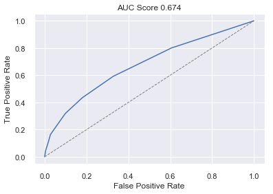

```python
from sklearn.metrics import roc_curve

fpr, tpr, _ = roc_curve(test_y, probabilities[:, 1])
plt.plot(fpr, tpr)
plt.plot([0, 1], [0, 1], color='grey', lw=1, linestyle='--')
plt.xlabel('False Positive Rate')
plt.ylabel('True Positive Rate')
plt.title('AUC Score 0.674')
plt.show
```

### Predict on-time arrivals

To built a machine-learning model in order to predict whether a flight will arrive on time or late. This machine-learning model is to compute the likelihood that a flight will be on time.

This function takes as input a date and time, an origin airport code, and a destination airport code, and returns a value between 0.0 and 1.0 indicating the probability that the flight will arrive at its destination on time. It uses the machine-learning model you built in the previous lab to compute the probability. And to call the model, it passes a DataFrame containing the input values to predict_proba.

```python
def predict_delay(departure_date_time, origin, destination):
    from datetime import datetime

    try:
        departure_date_time_parsed = datetime.strptime(departure_date_time, '%d/%m/%Y %H:%M:%S')
    except ValueError as e:
        return 'Error parsing date/time - {}'.format(e)

    month = departure_date_time_parsed.month
    day = departure_date_time_parsed.day
    day_of_week = departure_date_time_parsed.isoweekday()
    hour = departure_date_time_parsed.hour

    origin = origin.upper()
    destination = destination.upper()

    input = [{'MONTH': month,
              'DAY': day,
              'DAY_OF_WEEK': day_of_week,
              'CRS_DEP_TIME': hour,
              'ORIGIN_ATL': 1 if origin == 'ATL' else 0,
              'ORIGIN_DTW': 1 if origin == 'DTW' else 0,
              'ORIGIN_JFK': 1 if origin == 'JFK' else 0,
              'ORIGIN_MSP': 1 if origin == 'MSP' else 0,
              'ORIGIN_SEA': 1 if origin == 'SEA' else 0,
              'DEST_ATL': 1 if destination == 'ATL' else 0,
              'DEST_DTW': 1 if destination == 'DTW' else 0,
              'DEST_JFK': 1 if destination == 'JFK' else 0,
              'DEST_MSP': 1 if destination == 'MSP' else 0,
              'DEST_SEA': 1 if destination == 'SEA' else 0 }]

    return model.predict_proba(pd.DataFrame(input))[0][0]
```

Compute the probability that a flight from New York to Atlanta on the evening of October 1 will arrive on time.

```python
predict_delay('1/10/2018 21:45:00', 'JFK', 'ATL')
```

```
0.6
```

```python
predict_delay('2/10/2018 21:45:00', 'JFK', 'ATL')
```

```
0.8
```

```python
predict_delay('2/10/2018 10:00:00', 'ATL', 'SEA')
```

```
1.0
```

### Plot predictions

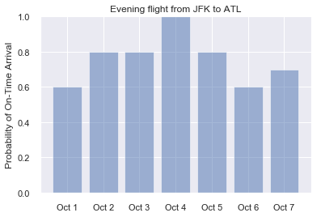

```python
import numpy as np

labels = ('Oct 1', 'Oct 2', 'Oct 3', 'Oct 4', 'Oct 5', 'Oct 6', 'Oct 7')
values = (predict_delay('1/10/2018 21:45:00', 'JFK', 'ATL'),
          predict_delay('2/10/2018 21:45:00', 'JFK', 'ATL'),
          predict_delay('3/10/2018 21:45:00', 'JFK', 'ATL'),
          predict_delay('4/10/2018 21:45:00', 'JFK', 'ATL'),
          predict_delay('5/10/2018 21:45:00', 'JFK', 'ATL'),
          predict_delay('6/10/2018 21:45:00', 'JFK', 'ATL'),
          predict_delay('7/10/2018 21:45:00', 'JFK', 'ATL'))
alabels = np.arange(len(labels))

plt.bar(alabels, values, align='center', alpha=0.5)
plt.xticks(alabels, labels)
plt.ylabel('Probability of On-Time Arrival')
plt.ylim((0.0, 1.0))
plt.title('Evening flight from JFK to ATL')
plt.show()
```